# case_study

Now, we want to check how the general placement and valedictorian placement vary by city. We use qplot.

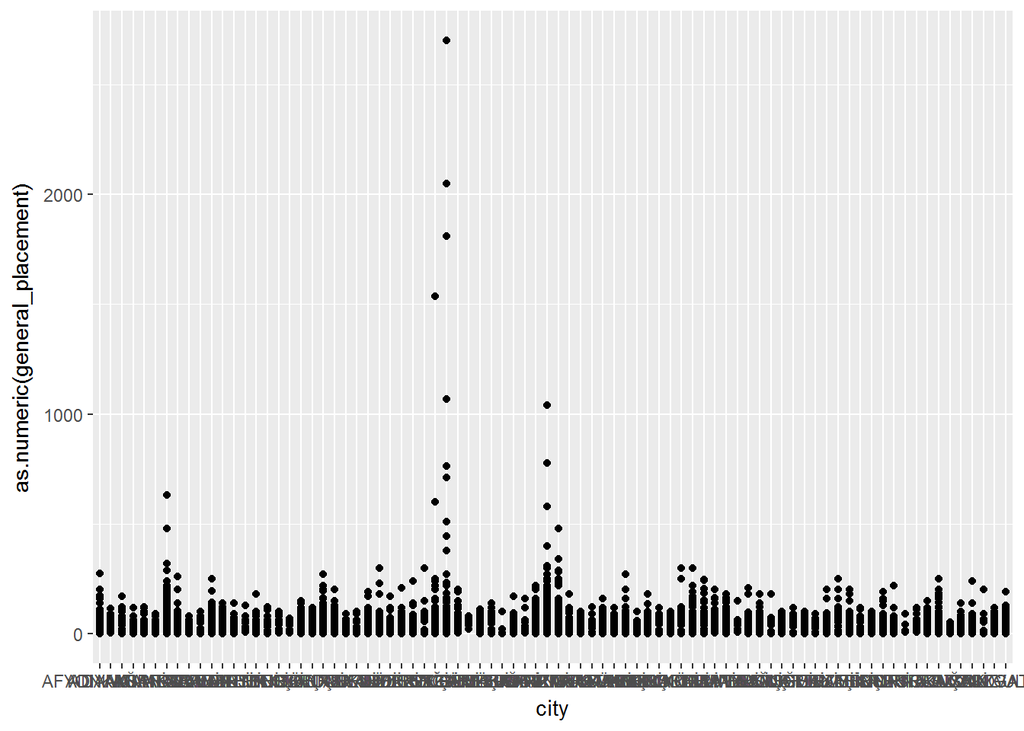

```r
qplot(city, as.numeric(general_placement), data=mydata1)
```

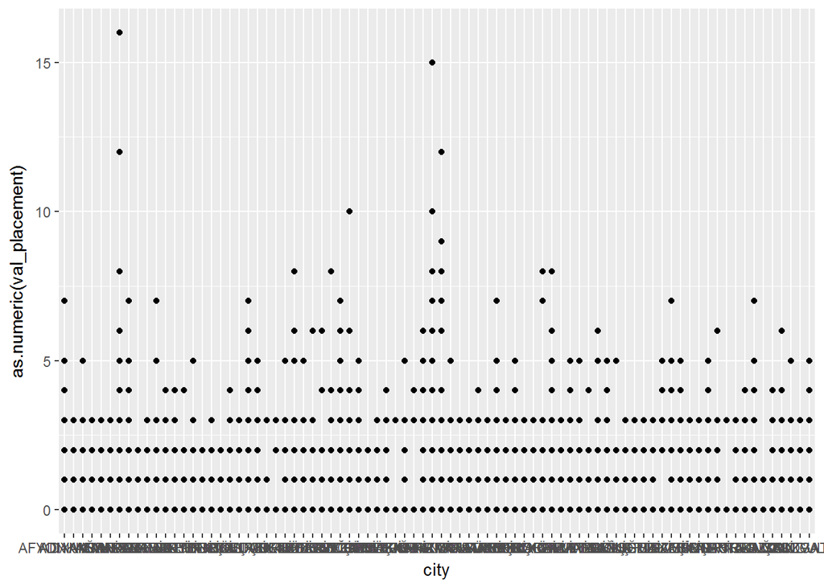

```r
qplot(city, as.numeric(val_placement), data=mydata1)
```

Here, we would like to filter our data and create mydata with the columns of mean of min scores, university names and statement if the university is MEF University or not(ismef).

```r
mydata <-
  osym_data_2017 %>% filter(floor(as.numeric(program_id)/100000000) %in% c(1,2)) %>% group_by(university_name) %>% summarise(mms=mean(min_score)) %>% mutate(ismef=(university_name == "MEF ?N?VERS?TES?"))

summary(mydata)
```

```
##  university_name         mms          ismef
##  Length:172         Min.   :237.2   Mode :logical
##  Class :character   1st Qu.:273.3   FALSE:172
##  Mode  :character   Median :293.9
##                     Mean   :301.1
##                     3rd Qu.:319.8
##                     Max.   :457.0
```

And we would like to check the distribution of mean of min_score

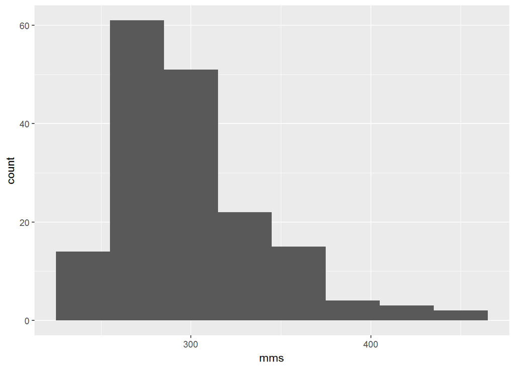

```r
qplot(mms, data=mydata, binwidth=30)
```

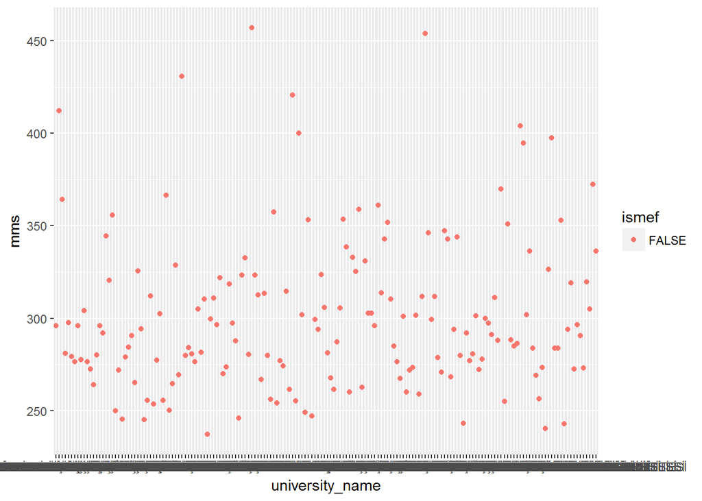

```r
ggplot(mydata, aes(x=university_name,y=mms)) + geom_point(aes(color=ismef))
```